# WLS Refrigeration Analysis

## Methodology

### Repeated measures ANOVA with follow-up paired comparisons

We ran a one-way repeated measures ANOVA:

$$\begin{aligned}
\text{Assay reading} & \sim \operatorname{Refrigeration
condition}(\mu, \zeta, \phi)
\end{aligned}$$

Where assay reading is a continuous variable containing the concentration from the different targets of interest ($\tau_{217}$, $NfL$, $GFAP$, $A\beta_{40}$, $A\beta_{42}$) or the ratio between $\frac{A\beta_{42}}{A\beta_{40}}$. On the other hand, refrigeration condition is a categorical variable with 3 levels (0 hrs, 48 hrs, 72 hrs), which represent the amount of time that the blood sample spent in refrigeration before freezing. For those analysis that showed significant difference between conditions, we ran paired follow-up comparisons between the refrigeration times. In the context of this analysis, a significant negative difference between a pair of conditions would suggest a reduction in the target concentration as a consecuence of the time spent refrigerated but not frozen.

### ICC

Additonally, we ran intraclass correlations between the three refrigeration conditions, to assess the reliability of the readings from the samples. The ICC is a value between 0 and 1. ICC values less than 0.5 are indicative of poor reliability, values between 0.5 and 0.75 indicate moderate reliability, values between 0.75 and 0.9 indicate good reliability, and values greater than 0.90 indicate excellent reliability. In the case of our samples, low reliability indicates lack of consistency in the readings, therefore a change in the target concentration due to the time spent without being frozen.

## Results

### Protein $\tau_{217}$

We did not find a significant difference between refrigeration levels and excellent reliability between the readings for Protein $\tau_{217}$.

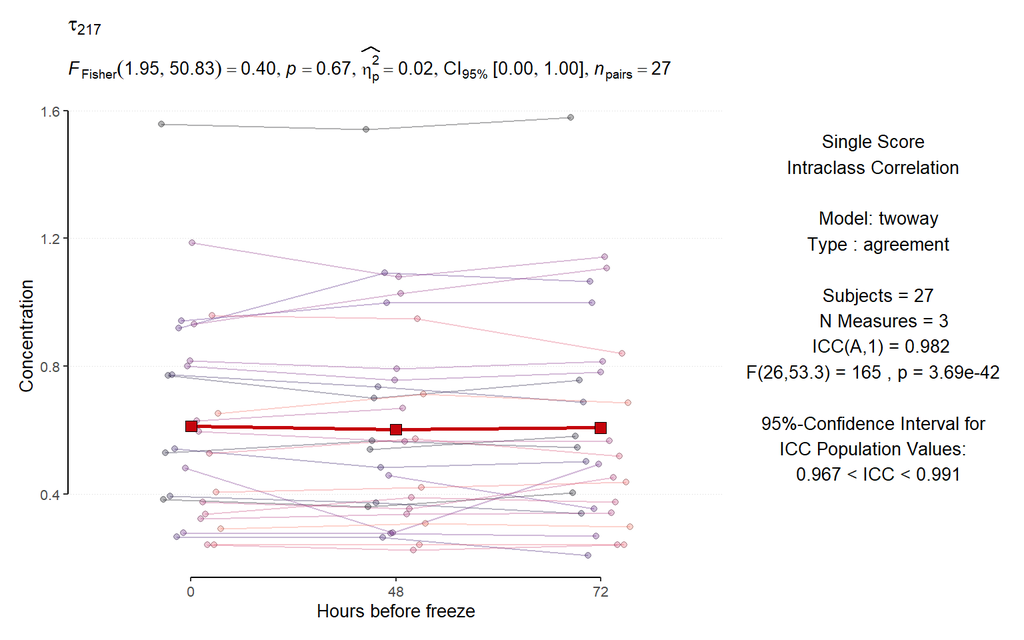

### Neurofilament light chain ($NfL$)

We did not find a significant difference between refrigeration levels and excellent reliability between the readings for $NfL$.

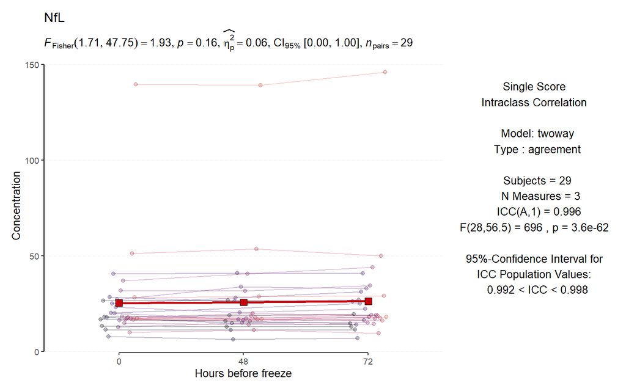

### Glial fibrillary acidic protein ($GFAP$)

We did not find a significant difference between refrigeration levels and excellent reliability between the readings for $GFAP$.

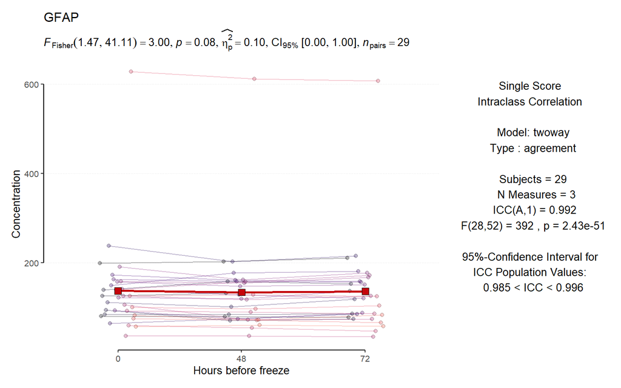

### Amyloid $\beta_{40}$ ($A\beta_{40}$)

We found a significant difference between samples frozen immediately and samples refrigerated for 48 hrs, and 72 hrs in terms of the concentration of $A\beta_{40}$. We also see poor reliability between the three conditions.

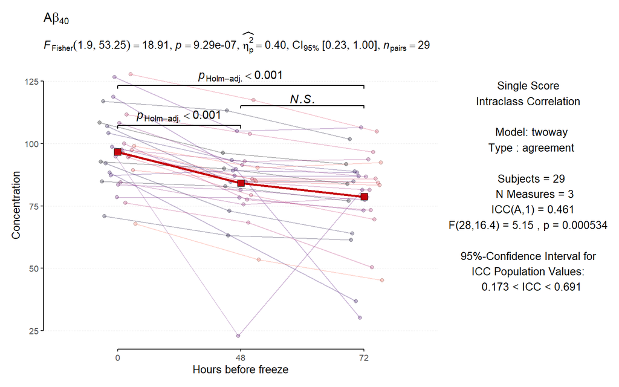

### Amyloid $\beta_{42}$ ($A\beta_{42}$)

We found a significant difference between samples frozen immediately and samples refrigerated for 48 hrs, and 72 hrs in the concentration of $A\beta_{42}$. We also see moderate reliability between the three conditions.

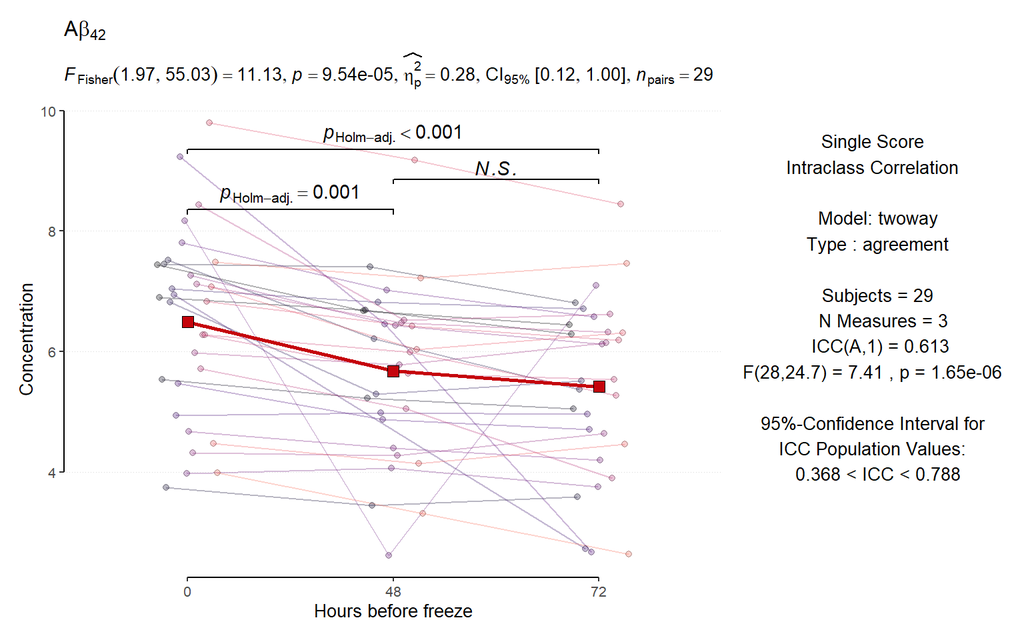

### $\text{Ratio } \frac{A\beta_{42}}{A\beta_{40}}$

We only found a significant difference between samples frozen immediately and samples refrigerated for 72 hrs in the ratio of $\frac{A\beta_{42}}{A\beta_{40}}$. We see good reliability between the three conditions. However, this is a composite measure, and we can see that the trend of the difference is upwards, indicating an increment in the proportion of $A\beta_{42}$ relative to $A\beta_{40}$, which may be due different decay rates experienced by these two targets.

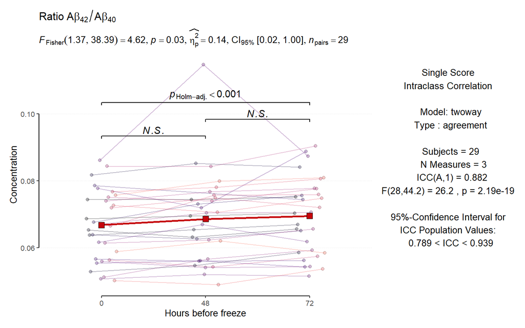